# Partie I - Prosper Loan Exploration de Données

### par *Christ Peryclais NGOLO*

## Introduction

> Ce document visualise l'ensemble de données sur les *prêts de Prosper*

## Preparation Préliminaire

```python
# Importer les bibliothèques nécessaires pour le travail
import numpy as np
import pandas as pd
import matplotlib.pyplot as plt
import seaborn as sns

%matplotlib inline
```

```python
# Charger l'ensemble de données dans un DataFrame Pandas
loan = pd.read_csv("prosperLoanData.csv")

# Afficher la taille et l'échantillon de nos données
print(loan.shape)
loan.head(5)
```

```
(113937, 81)
```

|  | ListingKey | ListingNumber | ListingCreationDate | CreditGrade | Term | LoanStatus | ClosedDate | BorrowerAPR | BorrowerRate | LenderYield | ... | LP_ServiceFees | LP_CollectionFees | LP_GrossPrincipalLoss | LP_NetPrincipalLoss | LP_NonPrincipalRecoverypayments | PercentFunded | Recommendations | InvestmentFromFriendsCount | InvestmentFromFriendsAmount | Investors |
| --- | --- | --- | --- | --- | --- | --- | --- | --- | --- | --- | --- | --- | --- | --- | --- | --- | --- | --- | --- | --- | --- |
| 0 | 1021339766868145413AB3B | 193129 | 2007-08-26 19:09:29.263000000 | C | 36 | Completed | 2009-08-14 00:00:00 | 0.16516 | 0.1580 | 0.1380 | ... | -133.18 | 0.0 | 0.0 | 0.0 | 0.0 | 1.0 | 0 | 0 | 0.0 | 258 |
| 1 | 10273602499503308B223C1 | 1209647 | 2014-02-27 08:28:07.900000000 | NaN | 36 | Current | NaN | 0.12016 | 0.0920 | 0.0820 | ... | 0.00 | 0.0 | 0.0 | 0.0 | 0.0 | 1.0 | 0 | 0 | 0.0 | 1 |
| 2 | 0EE9337825851032864889A | 81716 | 2007-01-05 15:00:47.090000000 | HR | 36 | Completed | 2009-12-17 00:00:00 | 0.28269 | 0.2750 | 0.2400 | ... | -24.20 | 0.0 | 0.0 | 0.0 | 0.0 | 1.0 | 0 | 0 | 0.0 | 41 |
| 3 | 0EF5356002482715299901A | 658116 | 2012-10-22 11:02:35.010000000 | NaN | 36 | Current | NaN | 0.12528 | 0.0974 | 0.0874 | ... | -108.01 | 0.0 | 0.0 | 0.0 | 0.0 | 1.0 | 0 | 0 | 0.0 | 158 |
| 4 | 0F023589499656230C5E3E2 | 909464 | 2013-09-14 18:38:39.097000000 | NaN | 36 | Current | NaN | 0.24614 | 0.2085 | 0.1985 | ... | -60.27 | 0.0 | 0.0 | 0.0 | 0.0 | 1.0 | 0 | 0 | 0.0 | 20 |

5 rows × 81 columns

```python
# Composistion ou information de base sur l'ensemble de données
loan.info()
```

```
<class 'pandas.core.frame.DataFrame'>
RangeIndex: 113937 entries, 0 to 113936
Data columns (total 81 columns):
 #   Column                               Non-Null Count   Dtype
---  ------                               --------------   -----
 0   ListingKey                           113937 non-null  object
 1   ListingNumber                        113937 non-null  int64
 2   ListingCreationDate                  113937 non-null  object
 3   CreditGrade                          28953 non-null   object
 4   Term                                 113937 non-null  int64
 5   LoanStatus                           113937 non-null  object
 6   ClosedDate                           55089 non-null   object
 7   BorrowerAPR                          113912 non-null  float64
 8   BorrowerRate                         113937 non-null  float64
 9   LenderYield                          113937 non-null  float64
```

[output cut: 73 more lines]

```python
# Les statistiques describes pour les varibles numériques
loan.describe()
```

|  | ListingNumber | Term | BorrowerAPR | BorrowerRate | LenderYield | EstimatedEffectiveYield | EstimatedLoss | EstimatedReturn | ProsperRating (numeric) | ProsperScore | ... | LP_ServiceFees | LP_CollectionFees | LP_GrossPrincipalLoss | LP_NetPrincipalLoss | LP_NonPrincipalRecoverypayments | PercentFunded | Recommendations | InvestmentFromFriendsCount | InvestmentFromFriendsAmount | Investors |
| --- | --- | --- | --- | --- | --- | --- | --- | --- | --- | --- | --- | --- | --- | --- | --- | --- | --- | --- | --- | --- | --- |
| count | 1.139370e+05 | 113937.000000 | 113912.000000 | 113937.000000 | 113937.000000 | 84853.000000 | 84853.000000 | 84853.000000 | 84853.000000 | 84853.000000 | ... | 113937.000000 | 113937.000000 | 113937.000000 | 113937.000000 | 113937.000000 | 113937.000000 | 113937.000000 | 113937.000000 | 113937.000000 | 113937.000000 |
| mean | 6.278857e+05 | 40.830248 | 0.218828 | 0.192764 | 0.182701 | 0.168661 | 0.080306 | 0.096068 | 4.072243 | 5.950067 | ... | -54.725641 | -14.242698 | 700.446342 | 681.420499 | 25.142686 | 0.998584 | 0.048027 | 0.023460 | 16.550751 | 80.475228 |
| std | 3.280762e+05 | 10.436212 | 0.080364 | 0.074818 | 0.074516 | 0.068467 | 0.046764 | 0.030403 | 1.673227 | 2.376501 | ... | 60.675425 | 109.232758 | 2388.513831 | 2357.167068 | 275.657937 | 0.017919 | 0.332353 | 0.232412 | 294.545422 | 103.239020 |
| min | 4.000000e+00 | 12.000000 | 0.006530 | 0.000000 | -0.010000 | -0.182700 | 0.004900 | -0.182700 | 1.000000 | 1.000000 | ... | -664.870000 | -9274.750000 | -94.200000 | -954.550000 | 0.000000 | 0.700000 | 0.000000 | 0.000000 | 0.000000 | 1.000000 |
| 25% | 4.009190e+05 | 36.000000 | 0.156290 | 0.134000 | 0.124200 | 0.115670 | 0.042400 | 0.074080 | 3.000000 | 4.000000 | ... | -73.180000 | 0.000000 | 0.000000 | 0.000000 | 0.000000 | 1.000000 | 0.000000 | 0.000000 | 0.000000 | 2.000000 |
| 50% | 6.005540e+05 | 36.000000 | 0.209760 | 0.184000 | 0.173000 | 0.161500 | 0.072400 | 0.091700 | 4.000000 | 6.000000 | ... | -34.440000 | 0.000000 | 0.000000 | 0.000000 | 0.000000 | 1.000000 | 0.000000 | 0.000000 | 0.000000 | 44.000000 |
| 75% | 8.926340e+05 | 36.000000 | 0.283810 | 0.250000 | 0.240000 | 0.224300 | 0.112000 | 0.116600 | 5.000000 | 8.000000 | ... | -13.920000 | 0.000000 | 0.000000 | 0.000000 | 0.000000 | 1.000000 | 0.000000 | 0.000000 | 0.000000 | 115.000000 |
| max | 1.255725e+06 | 60.000000 | 0.512290 | 0.497500 | 0.492500 | 0.319900 | 0.366000 | 0.283700 | 7.000000 | 11.000000 | ... | 32.060000 | 0.000000 | 25000.000000 | 25000.000000 | 21117.900000 | 1.012500 | 39.000000 | 33.000000 | 25000.000000 | 1189.000000 |

8 rows × 61 columns

```python
# La somme de valeurs manquantes par variable
loan.isna().sum().sort_values(ascending = True)
```

```
ListingKey                                  0
InvestmentFromFriendsAmount                 0
IncomeRange                                 0
IncomeVerifiable                            0
StatedMonthlyIncome                         0
                                        ...
ProsperPaymentsOneMonthPlusLate         91852
ProsperPaymentsLessThanOneMonthLate     91852
ScorexChangeAtTimeOfListing             95009
LoanFirstDefaultedCycleNumber           96985
GroupKey                               100596
Length: 81, dtype: int64
```

```python
# Afficher le pourcentage de valeurs manquantes
(loan.isna().sum() * 100 / loan.shape[0]).sort_values(ascending = True)
```

```
ListingKey                              0.000000
InvestmentFromFriendsAmount             0.000000
IncomeRange                             0.000000
IncomeVerifiable                        0.000000
StatedMonthlyIncome                     0.000000
                                         ...
ProsperPaymentsOneMonthPlusLate        80.616481
ProsperPaymentsLessThanOneMonthLate    80.616481
ScorexChangeAtTimeOfListing            83.387311
LoanFirstDefaultedCycleNumber          85.121602
GroupKey                               88.290898
Length: 81, dtype: float64
```

### La structure de cet ensemble de données :

> Il y a au total 113937 prêts dans cet ensemble de données avec 81 colonnes. La plus grande majorité des ces variables sont de nature numériques (quantitatives) mais, les variables comme LoanStatus, EmploymentStatus, Occupation, et CreditGrade sont des variables de catégorielles.

### Les principales caractéristiques intéressantes dans l'ensemble de données :

> Je suis plus intéressé dans les caractéristiques qui sont successibles de decrire les profils dont le montant des prêts sont les plus élevés, les plus accordés, ausi la note donnée à ces prêts en outre le nombre d'investisseurs ayant financé ce prêt

### Mes attentes de ces principales caractéristiques :

> J'attends à ce que les occupations des emprunteurs aient un grand impacte sur le montant des prêts, aussi les notes attribuées à chaque prêt, le total d'investisseurs ayant financé le prêt, les catégories de l'annonce et surtout les taux d'intérêts pour les prêts seront d'une grande aide pour cette enquête.

## Exploration des données univariées

> Je commencerai par regarder la distribution de la variable principale de l'intérêt : `LoanOriginalAmount`
- Définition de la fonction traçant les histogrammes

```python
# Définir la fonction
def plot_hist(df, x, cases):
    # Traçage de la figure
    plt.hist(data = df, x = x, bins = cases)
```

#### Comment sont disttribués les montants de prêts ?

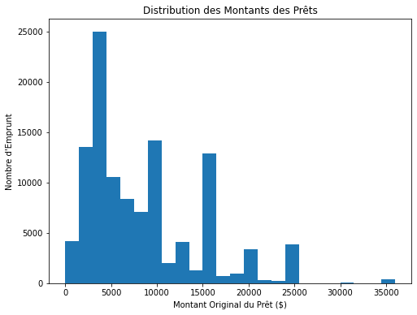

```python
# Dimensionner l'espace de travil
plt.figure(figsize=(8, 6))

# La taille de cases
binsize = 1500
# Définir le nombre de casiers (cases) à avoir
bins = np.arange(0, loan.LoanOriginalAmount.max()+binsize, binsize)

# Appel à la fonction pour visualiser les montants des prêts
plot_hist(loan, "LoanOriginalAmount", bins)
# Titre de la figure
plt.title("Distribution des Montants des Prêts")
# Etiquetter l'axe des x
plt.xlabel("Montant Original du Prêt ($)")
# Labeliser l'axe des y
plt.ylabel("Nombre d'Emprunt");
```

#### Quels groupes d'investisseurs ont financé plus de prêts ?

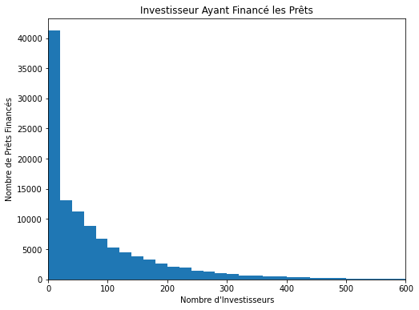

```python
# Taille des cases
binsize = 20
bins = np.arange(0, loan.Investors.max()+binsize, binsize)

# Dimensionner l'espace de travail
plt.figure(figsize=(8, 6))
# Faire appel à la fonction pour la visualisation
plot_hist(loan, "Investors", bins)
# Titre de la figure
plt.title("Investisseur Ayant Financé les Prêts")
# Limiter les valeurs de x à visualiser
plt.xlim([0, 600])
# labeliser l'axe des x
plt.xlabel("Nombre d'Investisseurs")
# Labeliser l'axe des y
plt.ylabel("Nombre de Prêts Financés");
```

> *Les groupes de `1 - 25` investisseurs ont financé le plus grand nombre de prêts parmi ces tous les investisseurs*

#### Comment sont distribués les taux d'intérêts des emprunteurs en fonction de la densité ?

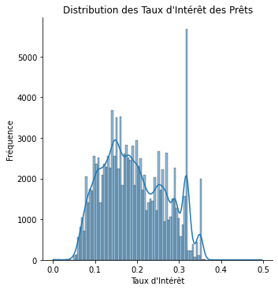

```python
sns.displot(data = loan, x = "BorrowerRate", kde = True, palette = "icefire_r")
# Titrer la figure
plt.title("Distribution des Taux d'Intérêt des Prêts")
# labeliser les axes
plt.xlabel("Taux d'Intérêt")
plt.ylabel("Fréquence");
```

```python
# Définir la fonction
def plot_bar(df, x, ordre, couleur):
    sns.countplot(data = df, x = x, order = ordre, color = couleur)
```

#### Quelles côtes de crédit attribuées à l'inscription sont les plus fréquentes ?

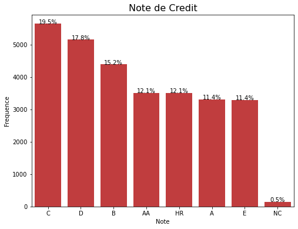

```python
# Somme des valeurs non nulles de la colonne "CreditGrade"
n_loan = loan.CreditGrade.value_counts().sum()

# Prendre les données dans l'ordre décroissante
order = loan.CreditGrade.value_counts().index
# Utiliser la couleur unique pour chaque categorie
color = sns.color_palette()[3]

# Dimensionner l'espace de travail
plt.figure(figsize=(8, 6))
# Visualisation des notes en faisant appel à la fonction
plot_bar(loan, "CreditGrade", order, color)

# Recalculer les notes de crédit
type_credit = loan["CreditGrade"].value_counts()

# Obtenir les emplacements et les étiquettes des ticks actuels
locs, labels = plt.xticks(rotation = 0)

# Boucler sur chaque paire d'emplacement et d'étiquettes
for loc, label in zip(locs, labels):
    # Récuperation de la propriété texte de l'étiquette pour obtnir le crédit correct
    credit = type_credit[label.get_text()]
    pct_string = "{:0.1f}%".format(100*credit/n_loan)

    # imprimer l'annotation juste en dessous du haut de la barre
    plt.text(loc, credit+2, pct_string, ha = 'center', color = 'black')

# Titre de la figure
plt.title("Note de Credit", fontsize = 16)
# Labeliser les axes
plt.ylabel("Frequence")
plt.xlabel("Note");
```

> *Les côtes de crédit `C`, `D` et `B` attribuées à l'inscription sont de plus en plus prises par les emprunteurs ensuite vient les quatre `AA`, `HR`, `A` et `E` qui semblent elles aussi intéressées les emprunteurs*

#### Dans quelles catégories avons-nous plus d'emprunts ?

- Types de catégories

#### Quelle est la fréquence de repartition des catégories d'annonces choisies par les emprunteurs lors de l'emprunt ?

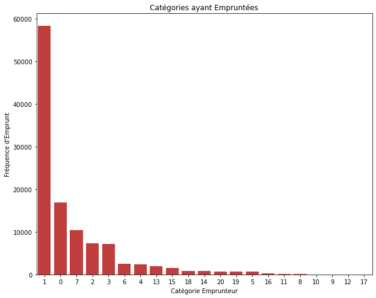

```python
# Prendre les catégories par ordre décroissant
order = loan["ListingCategory (numeric)"].value_counts().index
# Choix de la couleur unique à toutes les catégories
color = sns.color_palette()[3]

# Dimensionner l'espace de travail
plt.figure(figsize=(10, 8))
# Visualistion des catégories annoncées par les emprunteurs
plot_bar(loan, "ListingCategory (numeric)", order, color)
# Titre de la figure
plt.title("Catégories ayant Empruntées")
# Labeliser les axes
plt.xlabel("Catégorie Emprunteur")
plt.ylabel("Fréquence d'Emprunt");
```

#### Quelles sont les types d'occupations ayant plus empruntés ?

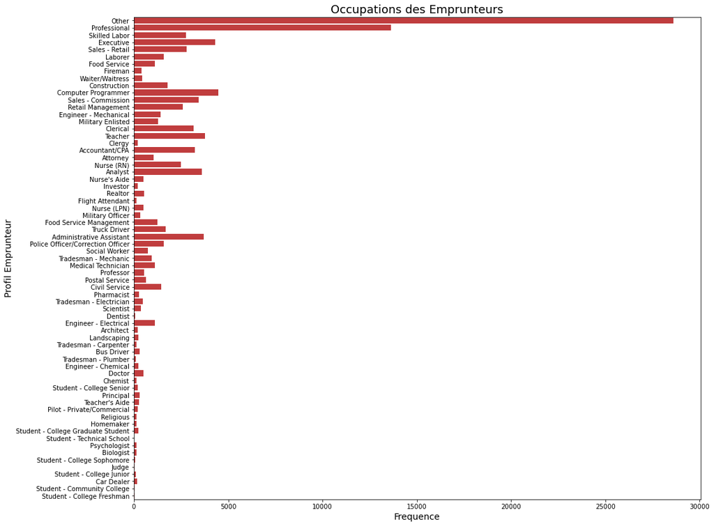

```python
# Choix de la couleur d'ensemble
color = sns.color_palette()[3]
# Dimensionner l'espace de travail
plt.figure(figsize=(16, 14))
# Visualiaton des Occupation des emprunteurs
sns.countplot(y = "Occupation", data = loan, color = color)
# Titrer la visualisation
plt.title("Occupations des Emprunteurs", fontsize = 18)
# Labeliser l'axe des y
plt.ylabel("Profil Emprunteur", fontsize = 14)
# Labeliser l'axe des x
plt.xlabel("Frequence", fontsize = 14);
```

> *On peut remarquer que les occupations de type `Other` sont en tête dans la liste des emprunteurs ensuite viennent les `Professional` qui eux aussi constituent des grands consommateurs de prêts*

#### Comment se comporte la fonction densité des montants de prêts ?

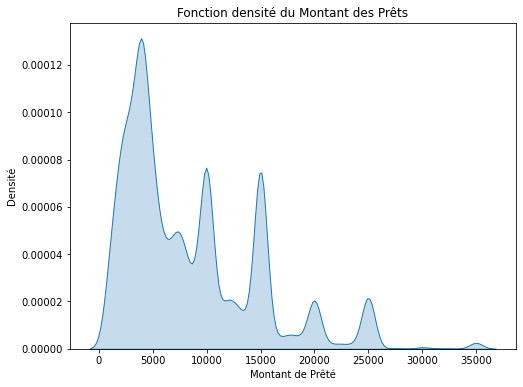

```python
# Dimensionner l'espace de travail
plt.figure(figsize=(8, 6))
# Repartition de "lv 50 HP"
sns.kdeplot(x = "LoanOriginalAmount", data = loan, shade = True)
# Titre du graphique
plt.title("Fonction densité du Montant des Prêts")
# Labeliser les axes
plt.xlabel("Montant de Prêté")
plt.ylabel("Densité");
```

> *Je n'ai pas observé de points inhabituels qui puissent influer sur mes données. Je n'ai pas vraiment eu des besoin de transformation mais toutefois, cela est psossible d'en effectuer quelques unes.*

> *Non, il n'y a pas du tout de distribution inhabituelles qui ont été remarquées!*

## Exploration de données Bivariées

#### Quelle est la relation entre les catégories d'annonce et le nombre d'investisseurs ayant contribué au prêt ?

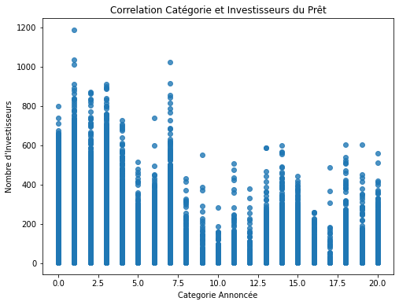

```python
# Dimensionner l'espace de travail
plt.figure(figsize=(8, 6))
sns.regplot(x = "ListingCategory (numeric)", y = "Investors",
            data = loan, fit_reg = False)
plt.title("Correlation Catégorie et Investisseurs du Prêt")
# Etiqutter l'axe des x
plt.xlabel("Categorie Annoncée")
# Etiquetter l'axe des y
plt.ylabel("Nombre d'Investisseurs");
```

#### Qu'on est-il de cette correlation en prennant en compte la transformation logarithmique ?

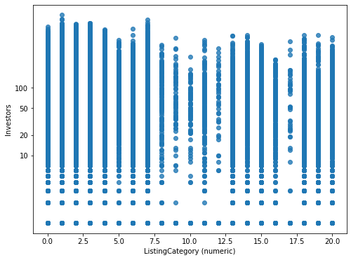

```python
# Définition de la fonction logarithmique
def log_trans(x, inverse = False):

    # Si la donnée n'est pas l'inverse alors, on retourne le log de 10
    if not inverse:
        return np.log10(x)
    # Sinon on retourne la fonction puissance
    else:
        return np.power(10, x)

# Dimensionner l'espace de Travail
plt.figure(figsize=(8, 6))
sns.regplot(x = loan["ListingCategory (numeric)"],
            y = loan["Investors"].apply(log_trans), fit_reg = False)
tick_locs = [10, 20, 50, 100]
plt.yticks(log_trans(tick_locs), tick_locs);
```

> *Une fois la fonction inverse appliquée, on observe une légère `distorsion` ou deséquilibré au niveau des deux variables*

#### Quelles sont les distributions des statuts d'employabilité suivant le montant des prêts ?

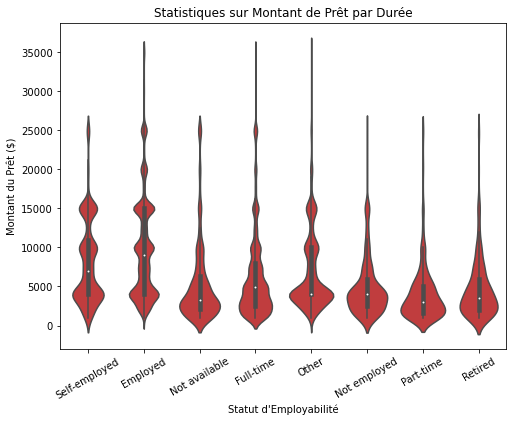

```python
# Dimensionner l'espace de travail
plt.figure(figsize=(8, 6))
sns.violinplot(x = "EmploymentStatus", y = "LoanOriginalAmount",
               data = loan, color = color)
# Titre de la figure
plt.title("Statistiques sur Montant de Prêt par Durée")
# Labeliser les axes
plt.xlabel("Statut d'Employabilité")
plt.ylabel("Montant du Prêt ($)")
# Pivoter les étiquettes de l'axe des x à 30°
plt.xticks(rotation = 30);
```

> *Après analyse faite, les statut `Employed` et `Self-employed`ont respectivement le 1er, le 3ème quartile et la médiane les plus élevés que tout les autres statuts*

#### Quel est l'ensemble de statistiques descriptives des catégories des prês de chaque état (statut) du prêt ?

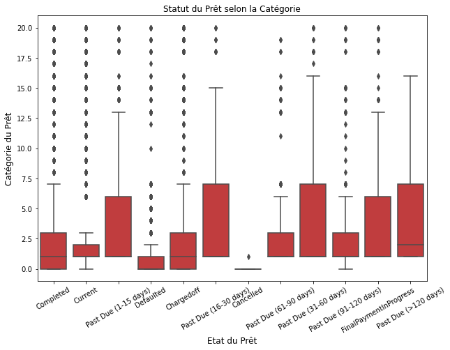

```python
# Utiliser une couleur unique pour tout le graphique
color = sns.color_palette()[3]

# Dimensionner l'espace de travail
plt.figure(figsize=(10, 7))
# Visualisation de Note en fonction du nombre de mois
sns.boxplot(x = "LoanStatus", y = "ListingCategory (numeric)",
               data = loan, color = color)
# Titre de la figure
plt.title("Statut du Prêt selon la Catégorie")
# Etiquetter l'axe des x
plt.xlabel("Etat du Prêt", fontsize = 12)
# Etiquetter l'axe des y
plt.ylabel("Catégorie du Prêt", fontsize = 12)
# Pivoter les étiquettes de l'axe x à 30°
plt.xticks(rotation = 30);
```

> *Nous pouvons observer un très grand nombre de valeurs aberrantes `outliers` dans ce résumé de données qui, signale un ensemble de statistiques descriptives sur les `catégories de prêts` de chaque `statut d'emprunt`*

#### Quelle est la fréquence de notes de crédit selon l'état des prêts ?

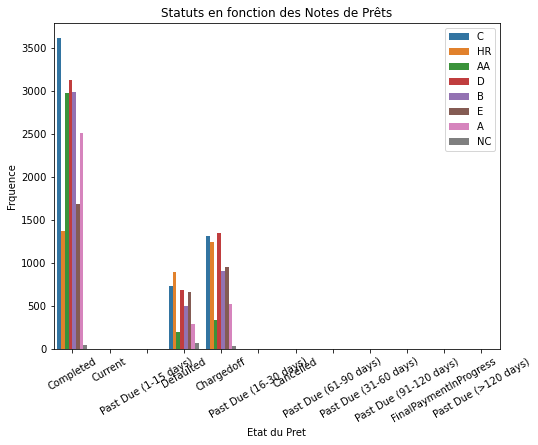

```python
# Dimensionner l'espace de travail
plt.figure(figsize=(8, 6))
sns.countplot(x = "LoanStatus", data = loan, hue = "CreditGrade")
# Mettre la légende en haut tout à droite
plt.legend(loc = "upper right")
# Titrer la figure
plt.title("Statuts en fonction des Notes de Prêts")
# Pivoter les étiquettes de l'axe x à 30°
plt.xticks(rotation = 30)
# Etiquetter l'axe
plt.xlabel("Etat du Pret")
# Etiquetter l'axe des y
plt.ylabel("Frquence");
```

> *Le statut de prêt `Completed` à lui seul répresente une grande partie des `notes de crédit` `C`, `D` et `B` attribuées lors de l'inscription pour le prêts.*

#### Quelle est la fréquence de notes de crédit selon le statut d'employabilité des emprunteurs ?

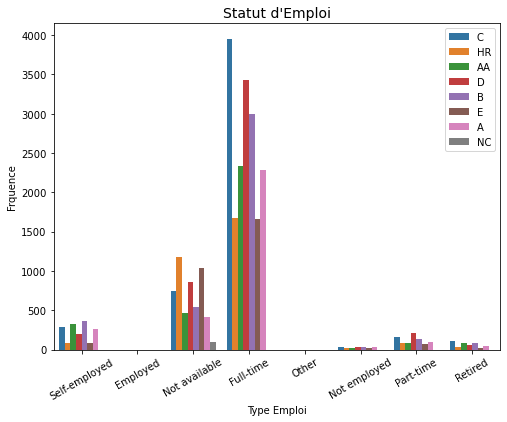

```python
# Dimensionner l'espace de travail
plt.figure(figsize=(8, 6))
sns.countplot(x = "EmploymentStatus", data = loan, hue = "CreditGrade")
# Mettre la légende en haut tout à droite
plt.legend(loc = "upper right")
# Titrer la figure
plt.title("Statut d'Emploi", fontsize = 14)
# Labeliser les axes
plt.ylabel("Frquence")
plt.xlabel("Type Emploi")
# Pivoter les étiquettes de l'axe x à 30°
plt.xticks(rotation = 30);
```

> *Le statut d'employabilité `Full-time` à lui seul répresente une grande partie des notes de crédit `C`, `D` et `B` attribuées lors de l'inscription des emprunteurs.*

#### Quelles sont les relations entre les notes de credit et les montants des prêts ?

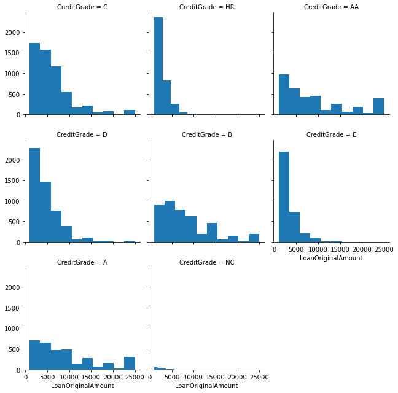

```python
# Tracer la facette
grid = sns.FacetGrid(col = "CreditGrade", data = loan, col_wrap = 3)
# Apliquer l'histogramme sur cette facette
grid.map(plt.hist, "LoanOriginalAmount");
```

> *Il y a une forte distribution entre les notes de credit `CreditGrade` `D`, `C` et `B` et le montant original des prêts `LoanOriginalAmount`*

> *Tout au long de cette étape, nous avons pu remarqué que les caractéristiques d'intérêt varie drastiquement avec les catégories `CreditGrade`, `LoanStatus` et aussi avec `EmploymentStatus`*

> *Les relations entre `CreditGrade` - `EmploymentStatus` et `CreditGrade` - `LoanStatus` semblent aussi intéressantes en ce qui concerne la distribution*

#### Il y a t-il quelque chose d’intéréssant entre "LenderYiel" et "BorrowerRate" ?

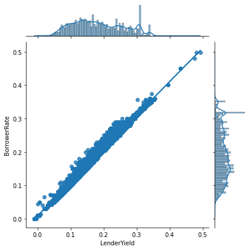

```python
# Visualisation pour voir cela en détail
sns.jointplot(data = loan, x = "LenderYield", y = "BorrowerRate", kind = "reg");
```

> *En effet, il y a quelque chose de d'intéressant entre ces deux variables, et l'on peut vraiement constater une très belle correlation entre elles.*

## Exploration Multivariée

#### Quelles sont les différentes palettes de couleurs que nous avons pour représenter nos données ?

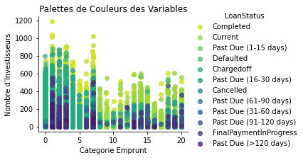

```python
# Création de la facette
g = sns.FacetGrid(data = loan, hue = "LoanStatus",
                  aspect = 1.4, palette = "viridis_r")
# Utilisation de la facette
g = g.map(sns.regplot, "ListingCategory (numeric)", "Investors",
          x_jitter = 0.04, fit_reg = False)
# Titrer la figure
plt.title("Palettes de Couleurs des Variables")
# Ajouter la légende
g.add_legend()
# Labeliser les axes
plt.xlabel("Categorie Emprunt")
plt.ylabel("Nombre d'Investisseurs");
```

#### Quelle est la relation qui existe entre nos quelques variables numériques ?

```python
# Créer une liste avec quelques colonnes numériques de notre ensemble de données
loan_stats = ["BorrowerAPR", "BorrowerRate", "LenderYield", "ListingCategory (numeric)", "Term"]
```

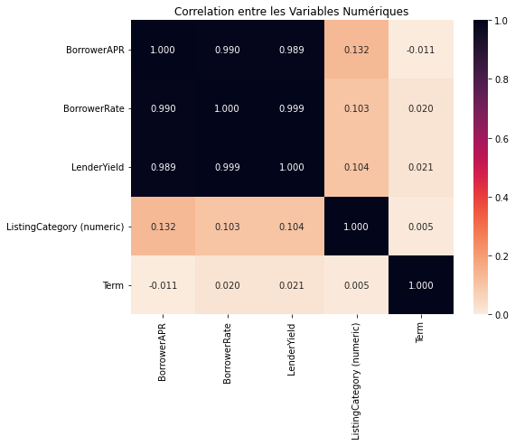

```python
#Dimensionner l'espace de travail
plt.figure(figsize=(8, 6))
sns.heatmap(loan[loan_stats].corr(), cmap = "rocket_r", annot = True, fmt = ".3f", vmin = 0)
# Titrer la figure
plt.title("Correlation entre les Variables Numériques");
```

#### Comment sera la relation entre "LenderYiel" et "BorrowerRate" on ajoutant les niveaux des côtes de crédit ?

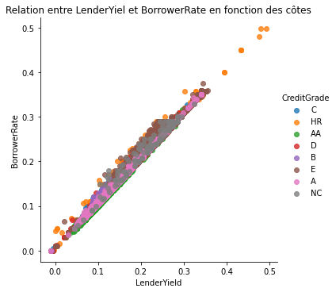

```python
# Visualisation de la presente relation
sns.lmplot(data = loan, x = "LenderYield", y = "BorrowerRate",
           hue = "CreditGrade", fit_reg = False)
# Titre de la firgure
plt.title("Relation entre LenderYiel et BorrowerRate en fonction des côtes");
```

> *On peut observer une correlation positive entre `LenderYield` et `BorrowerRate` selon les côtes de crédit `CreditGrade`*

## Conclusions

> *Tout au long de notre exploration de données, nous avons puis identifier des relations importantes entre nos différentes caractéristique d'intérêt mais aussi entre les autres caractéristiques. Cela a permi à ce que nous puissions élaborer quelques observations après chaque observation car, elles (observations) ont été pour nous un guide parfait pour l'élaboration de cette conclusion.*